# GSS challange

Desmond Koutso

Summer 2022

# Introduction

Is attitude toward capitol punishment (cappun) independent of race (race)? If not, then whose view differs from whom??

$H_0$: The attitude towards capitol punishment does not depend on the race.  
$H_A$: The attitude towards capitol punishment depends on the race.

# Methods

Both race and cappun are catregorical variables, so the analysis technique is CAT~CAT; plot is a barplot, summary is a cross-table, inference is chi-squared test. Also,the Fisher exact tests tells which races differ on opinion of capital punishment.

# Results

## Descriptive Results

### Graphical Descriptive Results

## Now with The Most data (fewer variables gives more data points)

```r
dd2 <- mydata %>% group_by(race,cappun) %>% summarize(count=n()) %>% mutate(prcnt=count/sum(count))
```

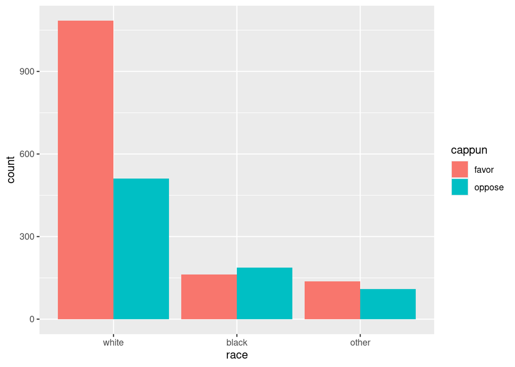

```r
# the group_by followed by summarize(count=n())

basicC <- ggplot(dd2,aes(x=race,y=count,fill=cappun))
basicC + geom_bar(stat="identity",position="dodge")
```

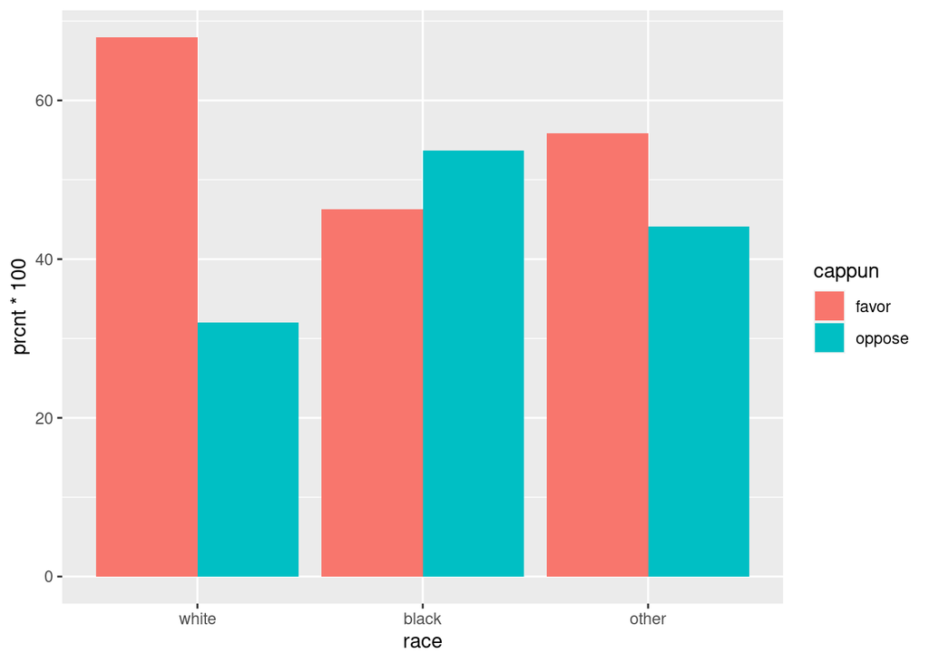

```r
#Now for percentage plot

basicCC <- ggplot(dd2,aes(x=race,y=prcnt*100,fill=cappun))
basicCC + geom_bar(stat="identity", position = "dodge")
```

from this plot, it appears that the white race is in favor of the cappun punishment as regard to the black or the other races.

### Numerical Descriptive Results

## Now with More data

```r
table2 <- xtabs(~race + cappun, data=mydata)
rowPerc(table2)
```

```
##        cappun
## race     favor oppose  Total
##   white  67.98  32.02 100.00
##   black  46.29  53.71 100.00
##   other  55.87  44.13 100.00
```

```r
colPerc(table2)
```

```
##        cappun
## race     favor oppose
##   white  78.34  63.24
##   black  11.70  23.27
##   other   9.96  13.49
##   Total 100.00 100.00
```

from the numerical data, it appears that the white race has a value of 67.98 in favor and 32.02 that opposes, the black race has 46.29 in favor and 53.71 that opposes and the other races has a 55.87 in favor and a 44.13 that opposes.

## More data version

```r
chisq.test(table2)
```

```
##
##  Pearson's Chi-squared test
##
## data:  table2
## X-squared = 64.42, df = 2, p-value = 1.027e-14
```

```r
chisqtestGC(table2)
```

```
## Pearson's Chi-squared test
##
## Observed Counts:
##        cappun
## race    favor oppose
##   white  1085    511
##   black   162    188
##   other   138    109
##
## Counts Expected by Null:
##        cappun
## race      favor oppose
##   white 1007.96 588.04
##   black  221.04 128.96
##   other  155.99  91.01
##
## Contributions to the chi-square statistic:
##        cappun
## race    favor oppose
##   white  5.89  10.09
##   black 15.77  27.03
##   other  2.08   3.56
##
##
## Chi-Square Statistic = 64.4201
## Degrees of Freedom of the table = 2
## P-Value = 0
```

```r
fisher.test(table2)
```

```
##
##  Fisher's Exact Test for Count Data
##
## data:  table2
## p-value = 2.033e-14
## alternative hypothesis: two.sided
```

```r
#fisherXY(mydata$race,mydata$cappun)
```

```r
fisherXY(mydata$cappun,mydata$race)
```

```
##
## contingency table:
##         y
## x        white black other
##   favor   1085   162   138
##   oppose   511   188   109
##
## ***All 2X2 tests****
##
## [1] "favor"  "oppose"
## [1] "white" "black"
##         y
## x        white black
##   favor   1085   162
##   oppose   511   188
##
##  Fisher's Exact Test for Count Data
##
## data:  fTempTable
## p-value = 5.75e-14
## alternative hypothesis: true odds ratio is not equal to 1
## 95 percent confidence interval:
##  1.934217 3.138838
## sample estimates:
## odds ratio
##   2.462836
##
##
## [1] "favor"  "oppose"
## [1] "white" "other"
##         y
## x        white other
##   favor   1085   138
##   oppose   511   109
##
##  Fisher's Exact Test for Count Data
##
## data:  fTempTable
## p-value = 0.0002819
## alternative hypothesis: true odds ratio is not equal to 1
```

[output cut: 9 more lines]

```
##         y
## x        black other
##   favor    162   138
##   oppose   188   109
##
##  Fisher's Exact Test for Count Data
##
## data:  fTempTable
## p-value = 0.02479
## alternative hypothesis: true odds ratio is not equal to 1
## 95 percent confidence interval:
##  0.4838949 0.9569306
## sample estimates:
## odds ratio
##  0.6810756
```

# Discussion and Conclusion